# RNA-seq analysis in R

Gene Set Testing for RNA-seq

Stephane Ballereau, Mark Dunning, Oscar Rueda, Ashley Sawle

Last modified: 31 Jul 2018

**Original Authors: Belinda Phipson, Anna Trigos, Matt Ritchie, Maria Doyle, Harriet Dashnow, Charity Law**, **Stephane Ballereau, Oscar Rueda, Ashley Sawle** Based on the course [RNAseq analysis in R](http://combine-australia.github.io/2016-05-11-RNAseq/) delivered on May 11/12th 2016 and modified by Cancer Research Uk Cambridge Centre for the [Functional Genomics Autumn School 2017](https://bioinformatics-core-shared-training.github.io/cruk-autumn-school-2017/)

## Resources and data files

This material has been created using the following resources:  
http://www.statsci.org/smyth/pubs/QLedgeRPreprint.pdf (Lun, Chen, and Smyth 2016)  
http://monashbioinformaticsplatform.github.io/RNAseq-DE-analysis-with-R/99-RNAseq_DE_analysis_with_R.html  
http://bioconductor.org/packages/devel/bioc/vignettes/DESeq2/inst/doc/DESeq2.html https://bioconductor.github.io/BiocWorkshops/rna-seq-data-analysis-with-deseq2.html

This section also uses code from Stephen Turner’s guide to fgsea https://stephenturner.github.io/deseq-to-fgsea/

# Gene Set Testing

In the early days of microarray analysis, people were happy if they got a handful of differentially-expressed genes that they could validate or follow-up. However, with later technologies (and depending on the experimental setup) we might have thousands of statistically-significant results, which no-one has the time to follow-up. Also, we might be interested in pathways / mechanisms that are altered and not just individual genes.

In this section we move towards discovering if our results are *biologically significant*. Are the genes that we have picked statistical flukes, or are there some commonalities.

There are two different approaches one might use, and we will cover the theory behind both

- There is also a bunch of websites for doing the tests
  - we will show how they are done in Bioconductor so the theory is clear
- We will assume we have done a differential-expression analysis, but the same techniques can be used for other situations when we have a gene list
  - ChIP-seq
  - RNA-seq

### fgsea analysis

The fgsea package is a free implementation of the Broad’s GSEA software and is described in more detail in the package [vignette](http://www.bioconductor.org/packages/release/bioc/vignettes/fgsea/inst/doc/fgsea-tutorial.html) “fast preranked gene set enrichment analysis (GSEA)”:

The GSEA analysis is performed by:

- 1. ranking all genes in the data set based on their correlation to the chosen phenotype,
- 2. identifying the rank positions of all members of the gene set, and
- 3. calculating an enrichment score (ES) that represents the difference between the observed rankings and that which would be expected assuming a random rank distribution.

> “After establishing the ES for each gene set across the phenotype, GSEA reiteratively randomizes the sample labels and retests for enrichment across the random classes. By performing repeated class label randomizations, the ES for each gene set across the true classes can be compared to the ES distribution from the random classes. Those gene sets that significantly outperform iterative random class permutations are considered significant.”

The article describing the original software is available [here](http://www.pnas.org/content/102/43/15545.long) and there is also a [commentary on GSEA](https://www.ncbi.nlm.nih.gov/pmc/articles/PMC1266131/).

In addition to the GSEA software the Broad also provide a number of very well curated gene sets for testing against your data - the Molecular Signatures Database (MSigDB). Unfortunately, these are collections of human genes. However, these lists have been translated to mouse equivalents by the Walter+Eliza Hall Institutes Bioinformatics service and made avaialble for download. These gene sets use *Entrez ID* as their identifier.

```r
head(results.annotated)
```

```
             ENSEMBL   baseMean log2FoldChange     lfcSE     stat        pvalue          padj  SYMBOL                                         GENENAME ENTREZID
1 ENSMUSG00000000381  398943.44       8.722325 0.3815879 22.94608 1.612341e-116 2.785480e-112     Wap                              whey acidic protein    22373
2 ENSMUSG00000061937 1134857.22       7.351405 0.3761569 19.72683  1.268851e-86  1.096033e-82 Csn1s2a                           casein alpha s2-like A    12993
3 ENSMUSG00000026417   11320.43       6.078220 0.3332017 18.13304  1.748099e-73  1.006672e-69    Pigr                polymeric immunoglobulin receptor    18703
4 ENSMUSG00000022491  514850.04       7.765956 0.4539439 17.96995  3.350319e-72  1.447003e-68 Glycam1 glycosylation dependent cell adhesion molecule 1    14663
5 ENSMUSG00000061388   30555.67       8.282907 0.4740455 17.36398  1.546169e-67  5.342324e-64 Csn1s2b                           casein alpha s2-like B    12992
6 ENSMUSG00000024903   60039.52       7.312158 0.4522371 16.27868  1.398616e-59  4.027083e-56    Lao1                           L-amino acid oxidase 1   100470
```

An appealing feature of the method is that it does not require us to impose arbitrary cut-offs on the dataset to decide what is differentially-expressed or not. The steps in producing the input required for GSEA are i) retrieving the ranked statistics ii) naming each one according to Entrez ID.

```r
filter(results.annotated, !is.na(ENTREZID))
```

[output not shown]

[output cut: 188 more lines]

[figure not shown]

```r
load("Robjects/mouse_H_v5p2.rdata")
pathways <- Mm.H
pathways[[1]]
```

```
  [1] "100040853" "100042651" "104681"    "105787"    "106628"    "106869"    "107771"    "107885"    "108078"    "108079"    "108767"    "110385"    "11303"     "11304"
 [15] "11305"     "11796"     "11797"     "11839"     "11848"     "11852"     "11853"     "11910"     "11941"     "12044"     "12045"     "12046"     "12047"     "12051"
 [29] "12053"     "12156"     "12226"     "12227"     "12228"     "12443"     "12505"     "12515"     "12519"     "12522"     "12575"     "12608"     "12609"     "12633"
 [43] "12649"     "12702"     "12778"     "12977"     "12981"     "13197"     "13537"     "13614"     "13636"     "13653"     "13654"     "13655"     "13660"     "14063"
 [57] "14066"     "14221"     "14281"     "14282"     "14283"     "14284"     "14345"     "14373"     "14528"     "14579"     "14583"     "14584"     "14595"     "14825"
 [71] "15200"     "15205"     "15370"     "15894"     "15902"     "15936"     "15937"     "15939"     "15945"     "15958"     "15980"     "16007"     "16160"     "16169"
 [85] "16173"     "16175"     "16176"     "16193"     "16195"     "16197"     "16323"     "16362"     "16367"     "16369"     "16449"     "16450"     "16476"     "16477"
 [99] "16598"     "16600"     "16601"     "16780"     "16835"     "16878"     "16977"     "170743"    "170755"    "170768"    "17118"     "17119"     "17126"     "17127"
[113] "17133"     "17210"     "17681"     "17691"     "17869"     "17872"     "17873"     "17940"     "17948"     "17951"     "17952"     "18024"     "18030"     "18033"
[127] "18034"     "18035"     "18037"     "18081"     "18124"     "18227"     "18412"     "18577"     "18578"     "18626"     "18627"     "18639"     "18640"     "18787"
[141] "18788"     "18792"     "18793"     "19219"     "19224"     "19225"     "19252"     "19262"     "192656"    "19267"     "19288"     "19347"     "194735"    "19696"
[155] "19697"     "19698"     "20229"     "20293"     "20296"     "20297"     "20303"     "20304"     "20307"     "20309"     "20310"     "20311"     "20393"     "20525"
[169] "20527"     "20620"     "20621"     "20623"     "20656"     "20698"     "20706"     "20707"     "20708"     "20709"     "20710"     "20719"     "20723"     "20725"
[183] "20726"     "20850"     "20851"     "20893"     "20918"     "20971"     "211770"    "211949"    "212225"    "21353"     "21354"     "21664"     "216850"    "21807"
[197] "21815"     "21847"     "21923"     "21926"     "21928"     "21929"     "21930"     "21942"     "21950"     "22029"     "22113"     "22114"     "22115"     "22151"
[211] "22152"     "22153"     "22154"     "22290"     "22339"     "22359"     "224109"    "22695"     "227613"    "227659"    "228839"    "229055"    "230073"    "230734"
[225] "230738"    "231130"    "236574"    "237300"    "23849"     "23872"     "23882"     "238871"    "239038"    "240672"    "24088"     "244882"    "246154"    "259300"
[239] "26397"     "26410"     "26559"     "268379"    "270198"    "27219"     "27262"     "27263"     "272667"    "27403"     "30945"     "319520"    "320560"    "320707"
[253] "321019"    "330122"    "381290"    "381390"    "381393"    "381741"    "381816"    "381979"    "382395"    "384059"    "384783"    "433486"    "436199"    "50723"
[267] "53418"     "53791"     "54199"     "54446"     "545486"    "54562"     "545814"    "54720"     "55991"     "56066"     "56193"     "56323"     "56336"     "56376"
[281] "56386"     "56644"     "56706"     "56708"     "56722"     "57440"     "57783"     "58864"     "59027"     "622474"    "622486"    "627035"    "627924"    "628596"
[295] "634967"    "635895"    "65112"     "654432"    "664821"    "66650"     "67035"     "67399"     "675165"    "67653"     "67916"     "67951"     "67972"     "68969"
[309] "70789"     "71099"     "71586"     "71712"     "73542"     "73710"     "74137"     "74511"     "74591"     "74646"     "75234"     "75770"     "77976"     "81489"
[323] "83430"     "83984"     "97848"     "98878"     "99929"
```

Conduct analysis:

```r
library(fgsea)
fgseaRes <- fgsea(pathways, ranks, minSize=15, maxSize = 500, nperm=1000)
```

```
There are duplicate gene names, fgsea may produce unexpected results
```

```r
class(fgseaRes)
```

```
[1] "data.table" "data.frame"
```

```r
dim(fgseaRes)
```

```
[1] 50  8
```

```r
#head(fgseaRes)
```

```r
fgseaResTidy <- fgseaRes %>%
  as_tibble() %>%
  arrange(desc(NES))
# Show in a nice table:
fgseaResTidy
```

```
# A tibble: 50 x 8
   pathway                                     pval    padj    ES   NES nMoreExtreme  size leadingEdge
   <chr>                                      <dbl>   <dbl> <dbl> <dbl>        <dbl> <int> <list>
 1 HALLMARK_OXIDATIVE_PHOSPHORYLATION       0.00209 0.00638 0.521  2.47            0   235 <chr [138]>
 2 HALLMARK_CHOLESTEROL_HOMEOSTASIS         0.00217 0.00638 0.571  2.40            0   100 <chr [42]>
 3 HALLMARK_PROTEIN_SECRETION               0.00212 0.00638 0.440  1.94            0   139 <chr [75]>
 4 HALLMARK_ADIPOGENESIS                    0.00209 0.00638 0.394  1.91            0   284 <chr [116]>
 5 HALLMARK_MTORC1_SIGNALING                0.00208 0.00638 0.362  1.75            0   276 <chr [104]>
 6 HALLMARK_FATTY_ACID_METABOLISM           0.00211 0.00638 0.372  1.74            0   208 <chr [80]>
 7 HALLMARK_BILE_ACID_METABOLISM            0.00206 0.00638 0.384  1.68            0   130 <chr [51]>
 8 HALLMARK_PEROXISOME                      0.00205 0.00638 0.361  1.62            0   146 <chr [56]>
 9 HALLMARK_HEME_METABOLISM                 0.00624 0.0142  0.283  1.36            2   264 <chr [74]>
10 HALLMARK_REACTIVE_OXIGEN_SPECIES_PATHWAY 0.0877  0.141   0.330  1.28           41    64 <chr [29]>
# ... with 40 more rows
```

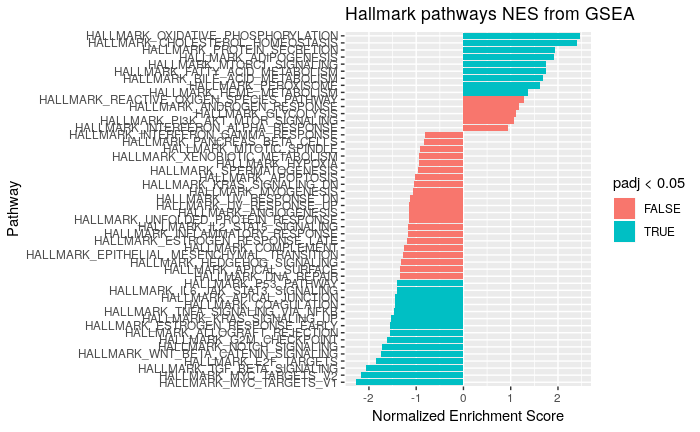

```r
library(ggplot2)
ggplot(fgseaResTidy, aes(reorder(pathway, NES), NES)) +
  geom_col(aes(fill=padj<0.05)) +
  coord_flip() +
  labs(x="Pathway", y="Normalized Enrichment Score",
       title="Hallmark pathways NES from GSEA")
```

The enrichment plot will show where the genes belonging to a particular gene set are towards the top or the bottom of the genelist, and how the *enrichment score* is calculated across the dataset.

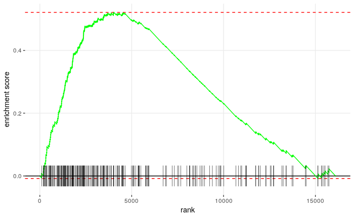

```r
plotEnrichment(pathways[["HALLMARK_OXIDATIVE_PHOSPHORYLATION"]],
               ranks)
```

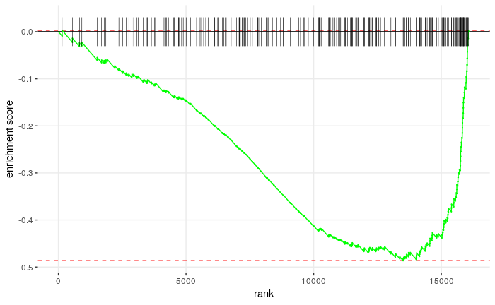

```r
plotEnrichment(pathways[["HALLMARK_MYC_TARGETS_V1"]],ranks)
```

```r
my_genes <- filter(results.annotated, ENTREZID %in% pathways[["HALLMARK_MYC_TARGETS_V1"]]) %>%
  pull(ENSEMBL)
vsd <- vst(dds)
```

```
using 'avgTxLength' from assays(dds), correcting for library size
```

```r
mat <- assay(vsd)[my_genes,]
mat <- mat - rowMeans(mat)
dim(mat)
```

```
[1] 245  12
```

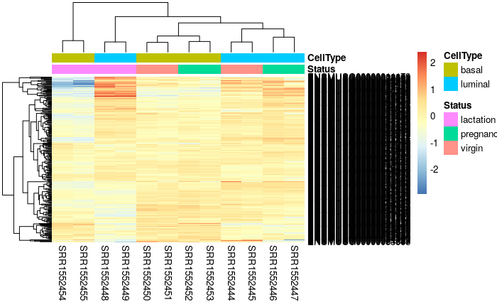

```r
rownames(sampleinfo) <- sampleinfo$run
pheatmap(mat,
         annotation_col = sampleinfo[,c("Status","CellType")])
```

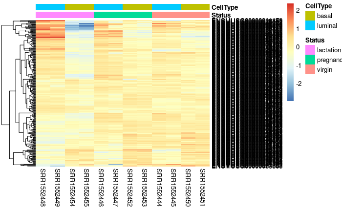

```r
pheatmap(mat[,order(colData(dds)$Status)],
         annotation_col = sampleinfo[,c("Status","CellType")],cluster_cols = FALSE)
```

## Gene Set Testing - competitive gene set tests

### GOseq analysis

GOseq is a method to conduct Gene Ontology (GO) analysis suitable for RNA-seq data as it accounts for the gene length bias in detection of over-representation ([GOseq article](https://genomebiology.biomedcentral.com/articles/10.1186/gb-2010-11-2-r14))

From the [GOseq vignette](https://www.bioconductor.org/packages/release/bioc/vignettes/goseq/inst/doc/goseq.pdf):

- GOseq first needs to quantify the length bias present in the dataset under consideration.
- This is done by calculating a Probability Weighting Function or PWF which can be thought of as a function which gives the probability that a gene will be differentially expressed (DE), based on its length alone.
- The PWF is calculated by fitting a monotonic spline to the binary data series of differential expression (1=DE, 0=Not DE) as a function of gene length.
- The PWF is used to weight the chance of selecting each gene when forming a null distribution for GO category membership.
- The fact that the PWF is calculated directly from the dataset under consideration makes this approach robust, only correcting for the length bias present in the data.

“GO analysis of RNA-seq data requires the use of random sampling in order to generate a suitable null distribution for GO category membership and calculate each category’s significance for over representation amongst DE genes. … In most cases, the Wallenius distribution can be used to approximate the true null distribution, without any significant loss in accuracy. The goseq package implements this approximation as its default option.”

Create list of DEGs:

```r
genes <- results.annotated$padj < 0.05 & !is.na(results.annotated$padj)
names(genes) <- results.annotated$ENSEMBL
```

Fit the Probability Weighting Function (PWF):

```
Can't find mm10/ensGene length data in genLenDataBase...
argument 'pattern' has length > 1 and only the first element will be usedFound the annotaion package, TxDb.Mmusculus.UCSC.mm10.knownGene
Trying to get the gene lengths from it.
initial point very close to some inequality constraints
```

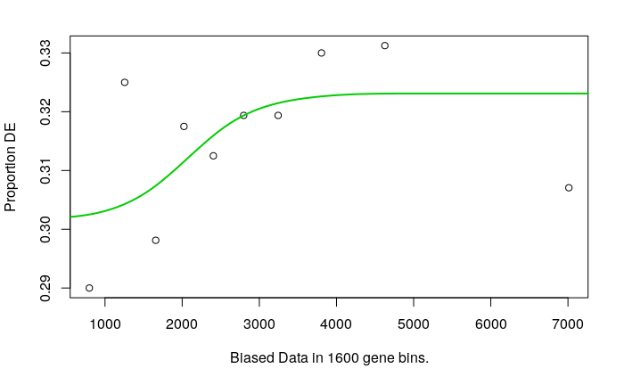

```r
library(goseq)
#print(supportedGeneIDs())
#print(supportedGenomes())
pwf <- nullp(genes, "mm10","ensGene")
```

## Creating Gene lists to use with an online tool

There are also many online tools that one could use to perform a gene set or ontology analysis.

- [DAVID](https://david.ncifcrf.gov/)
- [GeneTrail](https://genetrail2.bioinf.uni-sb.de/)
- [GORilla](http://cbl-gorilla.cs.technion.ac.il/)

The tools generally require your input genes lists to be uploaded as a simple text file. In this final challenge, we will create some files that you might use in one of these tools.

### A file containing names of background genes

This file has one column which lists **all the gene names** present in the analysis. Gene Symbols are commonly used, although a tool may accept Ensembl or Refseq names

### A file containing names of significant genes

This file has one column which lists the genes that passed the threshold for statistical significance (e.g. p-value less than 0.05) in your analysis. Gene Symbols are commonly used, although a tool may accept Ensembl or Refseq names

## Challenge

> Create two text files that can be imported into online tools for further analysis 1. A list of background genes 2. A list of differentially expressed genes 3. Load these files into GOrilla for analysis HINT: the `write.table` function is able to write a data frame to a txt file in R. You will need to set the appropriate arguments to make sure that a text file with only one column is created.

Lun, Aaron T L, Yunshun Chen, and Gordon K Smyth. 2016. “It’s DE-licious: A Recipe for Differential Expression Analyses of RNA-seq Experiments Using Quasi-Likelihood Methods in edgeR.” *Methods in Molecular Biology (Clifton, N.J.)* 1418 (January): 391–416. doi:10.1007/978-1-4939-3578-9\_19.